# Final Project

# 1 Project Overview

This final project requires you to analyze how a platform company from **your home country** has used platform strategies over the past five years (2021–2025), applying the platform strategies and rules you learned in this course. The company may be listed on a stock exchange or privately held.

## 1.1 Learning Objectives

By completing this project, you will:

- Apply the platform strategies and their rules from this course to a real company
- Use performance evidence (financial statements or public performance indicators) to judge whether a platform strategy worked
- Evaluate strategic shifts and their market impact
- Develop professional business reporting and presentation skills

# 2 Project Requirements

## 2.1 Scope and Duration

- **Duration**: Weeks 10–16
- **Team Size**: Individual
- **Final Presentations**: Weeks 15–16

## 2.2 Project Schedule

| When | What to submit or do | How to submit |
| --- | --- | --- |
| **Week 10** | **Chapter 1** (Company Introduction), with links to at least 3 performance indicators for company approval | PDF on iLearn: `StudentID_Name_Ch1.pdf` |
| **Week 14 (Friday, 5 pm)** | **Final report** (all chapters, references, and appendices), **slides**, and **5-minute presentation video** | PDFs on iLearn: `StudentID_Name_Report.pdf`, `StudentID_Name_Slides.pdf`; video on Google Drive, submit **only the link** on iLearn |
| **Weeks 15–16** | **Final presentations** in class (5 minutes + 1 minute Q&A), using **only the slides you submitted in Week 14** | Attend in person |

Write your report in the report template from Week 10, and keep adding to the same file. You will receive feedback on Chapter 1 after Week 10.

### 2.2.1 Weekly Activities (Recommended)

| Week | Recommended activities | Deadline this week |
| --- | --- | --- |
| **Week 10** | • Choose a platform company from your home country • Find links to at least 3 performance indicators • Write Chapter 1 in the template | **Chapter 1** |
| **Week 11** | • Read the Week 10 feedback and fix Chapter 1 • Collect 5 years (2021–2025) of performance evidence • Start the evidence table • Write Chapter 2 (Platform Diagnosis) | – |
| **Week 12** | • Choose 2–3 strategies, including one that failed or carries a risk • Fill in the rule-check tables • Make charts of the results | – |
| **Week 13** | • Write Chapter 3 (Strategy Analysis): what the company did, rule check, result, verdict | – |
| **Week 14** | • Write Chapter 4 (Recommendation) • Finish the references and appendices • Make at least 10 slides • Practice and record the 5-minute video • Check the format and convert to PDF | **Final report + slides + video link (Friday, 5 pm)** |
| **Weeks 15–16** | • Give your live presentation with the slides you submitted in Week 14 (no changes allowed) • Answer questions and listen to your classmates | **Presentation** |

## 2.3 Company Selection

**Select ONE company that meets the following criteria:**

1. **Home country**: The company was founded in, or has its headquarters in, **your home country**
2. **Listing status does not matter**: Both listed and privately held (unlisted) companies are allowed
3. **Platform business**: The company operates a platform, which means it connects two or more groups of users (for example, buyers and sellers, riders and drivers, or users and advertisers)
4. **Evidence available**: Public sources show how the company’s strategy changed over the **past 5 years (2021–2025)**, and you can find at least **3 performance indicators** reported by year (see *Performance Evidence* below)

### 2.3.1 Suggested Company Types

- Technology platforms (e.g., e-commerce, social media, sharing economy)
- Financial technology (fintech) platforms
- Traditional companies transitioning to platform models
- Marketplace operators
- Digital service providers

## 2.4 Performance Evidence

**Performance evidence** is any number that shows whether the company’s strategy worked. Many privately held companies do not publish financial statements, so you may use either type of evidence below.

**Option A – Financial statements** (if available)

- Annual reports or audited financial statements
- Revenue growth, revenue mix by business line, operating profit, and take rate (the share of each transaction the platform keeps)

**Option B – Public performance indicators** (if financial statements are not available)

Present **at least 3** of the following indicators, reported **by year**:

- Number of users, sellers, drivers, or other participants on each side of the platform
- Gross merchandise value (GMV), which is the total value of transactions on the platform
- App downloads or app store rankings
- Funding raised and company valuation from investment rounds
- Market share from industry reports or credible news media
- Figures published in the company’s own press releases or official blog

### 2.4.1 Where to Find Evidence

- **Listed companies**: your country’s stock exchange disclosure system and the company’s investor relations (IR) website
- **Privately held companies**: some countries require certain unlisted companies to publish audited statements in a public registry; check your country’s rules first. Otherwise, use the company’s press releases, app statistics sites, investment news, and industry reports.

### 2.4.2 Company Approval (Week 10)

When you submit Chapter 1, include **links to at least 3 performance indicators** (or one recent financial statement). A company will not be approved without these links. This check protects you from discovering late in the project that the evidence does not exist.

### 2.4.3 Evidence Table (Required Appendix A)

Attach an **evidence table** to your report. Every factual claim needs one row:

| Claim | Evidence (number or fact) | Source (link) | Year |
| --- | --- | --- | --- |
| *Example: The company raised commissions for sellers* | *Commission rose from 8% to 11%* | *Company press release (link)* | *2023* |

# 3 Analysis Framework

Your analysis has three parts. **Part A** describes the platform with the ideas from Module 1. **Part B** judges 2–3 strategies from Modules 2 and 3 with the rules you learned in class. **Part C** recommends what the company should do next.

## 3.1 Part A: Platform Diagnosis (Module 1)

Describe the platform before you judge its strategies. Answer each question in 2–3 sentences with evidence.

| Idea (Session) | Question to answer |
| --- | --- |
| **Two-sided network** (1.3) | Which groups does the platform connect? What does each group want from the other? |
| **Network effects** (1.2) | Does the platform become more useful as more users join? Is the effect direct (same group) or indirect (the other group)? |
| **Penguin effect** (1.2) | How did the company get its first users when nobody wanted to join first? |
| **Winner-takes-all** (1.4) | Is the market moving toward one winner? What is the company’s market position, and can users easily use rival platforms at the same time (multihoming)? |

## 3.2 Part B: Strategy Analysis (Modules 2 and 3)

Choose **2 or 3 strategies** from the menu below that the company actually used between 2021 and 2025. **At least one** of them must be a strategy that failed, partly failed, or carries a clear risk. Real companies make mistakes, and explaining a mistake shows real understanding.

### 3.2.1 Strategy Menu

[output not shown]

### 3.2.2 Four Steps for Each Strategy

Analyze every strategy you choose with the same four steps:

1. **What the company did**: Describe the move with the year and a source.
2. **Rule check**: For each rule of the strategy, decide whether the company **followed** it, **broke** it, or whether it is **unclear**, and give one piece of evidence. Use a table like this:

   | Rule | Followed / Broke / Unclear | Evidence (with source) |
   | --- | --- | --- |
   | Rule 1: … | Followed | … |
   | Rule 2: … | Broke | … |

3. **Result**: Show what happened, with at least one number from your performance evidence (before and after the move).
4. **Verdict**: Did the strategy work, fail, or is it too early to tell? Connect the verdict to the rule check.

### 3.2.3 Use the Class Tools

Reuse the tools and templates from each session (for example, the signal questions from Session 2.1, the subsidy calculation from Session 2.2, and the overlap rate and CAC comparison from Session 3.1). Your evidence will be stronger and your work will be faster.

## 3.3 Part C: Recommendation — “If I Ran This Company”

Imagine you are the owner of the company. Use the method from Session 2.4:

1. **Name the problem** the company faces today in one sentence, without a solution in it.
2. **Choose one strategy** from the menu to solve it, and show that its rules can be followed with evidence.
3. **Compare** it with one other option using the same numbers (expected result, time to result, main risk).
4. **Plan the next step**: which strategy should come after it, and why.

# 4 Deliverables

## 4.1 Written Report (at least 10 pages)

### 4.1.1 Format Requirements

- **Template**: Use the report template (Word, A4). Keep its headings and format.
- **Cover page**: the title (*Platform Strategy Analysis of [Company Name]*), the course name, your name, student ID, home country, and the submission date, as in the template.
- **Length**: **at least 10 pages** for sections 1–4. The cover page, references, and appendices do not count. You may write more.
- **File Format**: **PDF only**

| Item | Format |
| --- | --- |
| Paper size | A4 |
| Margins | 2.54 cm on all sides |
| Font | Times New Roman |
| Body text | 12 pt, line spacing 1.5 |
| Headings | 14 pt bold (level 1), 12 pt bold (levels 2 and 3) |
| Tables and figure captions | 10 pt; every table and figure has a number and a title (for example, *Table 1. Rule check for Asymmetric Pricing*) |
| Page numbers | Bottom center, starting after the cover page |
| Citations | APA 7th edition; references in alphabetical order |

Tables and figures count toward the 10 pages, but **at least 7 pages must be written text**.

### 4.1.2 Report Structure

| # | Section | What to write | Minimum pages |
| --- | --- | --- | --- |
| 1 | **Company Introduction** | What the company does, why you chose it, and the 2–3 strategies you will analyze | 1 |
| 2 | **Platform Diagnosis** (Part A) | The groups the platform connects, its network effects, how it won its first users, and its market position | 1.5 |
| 3 | **Strategy Analysis** (Part B) | For each strategy: (1) what the company did, (2) rule-check table, (3) result with numbers, (4) verdict. At least one strategy must have failed or carry a clear risk | 5 |
| 4 | **Recommendation: If I Ran This Company** (Part C) | “If I ran this company”: the problem in one sentence, the chosen strategy, a comparison with one other option, and the next step | 2.5 |
| 5 | **References** | All sources in APA 7th edition format, in alphabetical order | not counted |
| 6 | **Appendix A: Evidence Table** | One row per factual claim: claim, evidence, source link, year | not counted |
| 7 | **Appendix B: AI Use Disclosure** | Each AI tool you used and what you used it for, or “None” | not counted |

### 4.1.3 What to Write in Each Section

**1. Company Introduction** (1 page)

- What does the company do, and when was it founded?
- Why did you choose this company?
- Which 2–3 strategies will you analyze, and why these?

**2. Platform Diagnosis** (1.5 pages)

Write four sub-sections, as in the template:

- **2.1 Sides of the Platform**: Which groups does the platform connect? What does each group want from the other?
- **2.2 Network Effects**: Does the platform become more useful as more users join? Direct or indirect?
- **2.3 First Users (Penguin Effect)**: How did the company solve the penguin effect (nobody wants to join first)?
- **2.4 Market Position**: Is the company the leader? Is the market moving toward one winner? Do users also use rival platforms (multihoming)?

**3. Strategy Analysis** (5 pages, about 2 pages per strategy)

Write one sub-section for each strategy (3.1, 3.2, and the optional 3.3), with the same four parts:

1. **What the company did**: one paragraph describing what the company did, when (year), and why, with a source.
2. **Rule check**: a table with the four rules of the strategy. For each rule, write *Followed*, *Broke*, or *Unclear*, plus one piece of evidence with its source. Number each table (*Table 1. Rule check for [Strategy Name]*).
3. **Result**: numbers before and after the move (for example, users in 2021 and 2024). A simple chart is welcome.
4. **Verdict**: did it work, fail, or is it too early to tell? Explain which rules caused this result.

Remember: at least one strategy must have failed or carry a clear risk.

**4. Recommendation: If I Ran This Company** (2.5 pages)

Write as if you are the owner of the company:

1. **Problem**: the biggest problem the company faces today, in one sentence. Do not include the solution.
2. **Strategy**: the strategy you choose to solve it, and why its rules can be followed (with evidence).
3. **Comparison**: one other option, compared with the same numbers in a table (*Table 4. Comparison of options*: expected result, time to result, main risk).
4. **Next step**: which strategy should come after this one, and why.

**5. References**

- Every source in your report, in APA 7th edition format, in alphabetical order.

**6. Appendix A: Evidence Table**

- One row for every factual claim in the report: *claim*, *evidence (number or fact)*, *source link*, *year*.

**7. Appendix B: AI Use Disclosure**

- Each AI tool you used and what you used it for (for example, grammar checking). Write “None” if you did not use AI tools.

## 4.2 Presentation Slides (at least 10 slides)

### 4.2.1 Format Requirements

- **Length**: **at least 10 slides**. You may use more, but the presentation must still fit in 5 minutes.
- **File Format**: **PDF only**

### 4.2.2 Suggested Slide Plan

| Minimum slides | Content |
| --- | --- |
| 1 | Title: your title, your name, and student ID (and, if you used AI for the slides, the AI tool’s name and your prompts) |
| 2 | Company introduction and platform diagnosis (Part A) |
| 4–5 | Strategy analysis (Part B): about 2 slides per strategy (rule-check table, result) |
| 2 | Recommendation: “If I ran this company” (Part C) |
| 1 | Summary |

If you used an AI tool to make the slides, show the **AI tool’s name and your prompts on the title slide**, as in Figure 1.

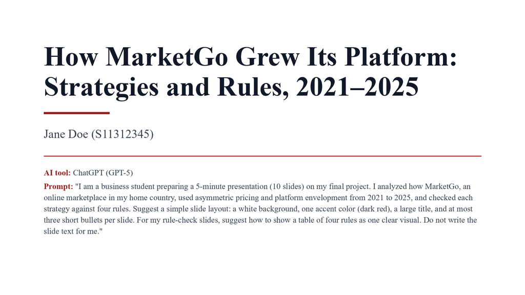

Figure 1: Example title slide: title, author, and AI use (fictional student and company; the prompt is only an example)

## 4.3 Presentation Video (5 minutes)

- Record your 5-minute presentation in English.
- **Only you need to be in the video:** your face must be visible throughout. Slides are not needed in the video.
- **Sample video:** [A Plan Is Not a Strategy](https://youtu.be/iuYlGRnC7J8) (Harvard Business Review; Figure 2). Watch it for the format:
  - One speaker, framed from the waist up, in the middle of the screen.
  - A plain, quiet background with nothing distracting behind the speaker.
  - The speaker looks at the camera and talks to the viewer, using natural hand gestures, without reading from a script.
  - Only a short caption with the speaker’s name appears on screen. No slides.
- Upload the video to Google Drive. Set sharing to **“Anyone with the link”** with the role **Viewer**, and submit the link in iLearn by the Week 14 deadline.

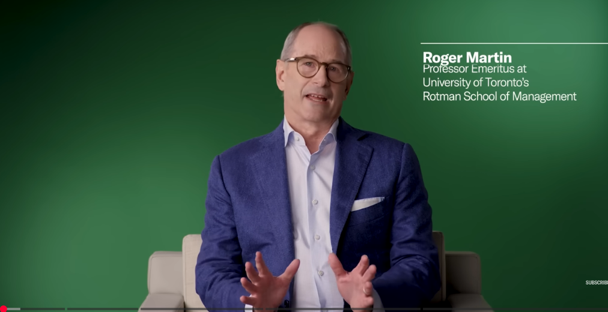

Figure 2: A frame from the sample video: one speaker, waist up, plain background, no slides. Source: Harvard Business Review, “A Plan Is Not a Strategy” (YouTube).

## 4.4 Deadline

See the **Project Schedule** above: final report, slides, and video link are all due **Week 14, Friday, 5 pm**.

# 5 Presentation Guidelines

## 5.1 Final Presentations (Weeks 15–16)

- **Duration**: 6 minutes total
  - 5 minutes presentation
  - 1 minute Q&A
- **Attendance**: Mandatory
- **Slides**: You present **only with the slides you submitted in Week 14**. You **cannot change** your slides on the presentation day.

## 5.2 Presentation Structure (5 minutes)

Suggested time allocation:

| Section | Time |
| --- | --- |
| Company Overview & Platform Diagnosis (Part A) | 1:00 |
| Strategy Analysis (Part B, 2–3 strategies) | 2:30 |
| Recommendation: “If I Ran This Company” (Part C) | 1:00 |
| Summary | 0:30 |

Practice your presentation multiple times to stay within the 5-minute limit. Presentations will be stopped at 5 minutes.

## 5.3 Q&A Session (1 minute)

Be prepared to answer questions about:

- Methodology and data sources
- Specific strategic choices by the company
- Performance evidence and its sources
- Why you judged a rule as followed or broken
- Alternative interpretations

# 6 Submission Requirements

## 6.1 Deadline

| Deadline | Submission |
| --- | --- |
| Week 10 | Chapter 1 (PDF) |
| Week 14 (Friday, 5 pm) | Final report (PDF), slides (PDF), and link to the presentation video (Google Drive) |

## 6.2 Submission Process

1. **Convert to PDF**: Ensure both report and slides are in PDF format
2. **Name your files**: use the file names in the **Project Schedule** (for example, `StudentID_Name_Report.pdf`)
3. **Check the video link**: Open it in a private browser window to make sure anyone can view it
4. **Submit to iLearn**: Upload each file, or the video link, to the submission folder for that deadline

### 6.2.1 Important Notes

- Late submissions will be penalized according to course policy
- Only PDF format will be accepted
- Ensure files are not corrupted before submission
- The slides you submit in Week 14 are the slides you present; you cannot change them on the presentation day

# 7 Evaluation

| Item | Points |
| --- | --- |
| Written Report | 30 |
| In-class Presentation (Weeks 15–16) | 70 |
| **Total** | **100** |

# 8 Resources and Support

## 8.1 Data Sources

### 8.1.1 Company Sources

- Annual reports and audited financial statements (listed companies, or unlisted companies that must publish them)
- Stock exchange disclosure systems and company investor relations websites
- Company press releases, official blogs, and founder interviews

### 8.1.2 Public Performance Indicators

- App statistics sites (downloads, rankings)
- Investment news and startup databases (funding rounds, valuation)
- Credible news media reporting user numbers or market share

### 8.1.3 Industry Analysis

- Industry reports (Gartner, Forrester, IDC)
- Market research firms
- Trade publications
- Academic journals

# 9 Tips for Success

## 9.1 Analysis Approach

1. **Start Early**: Choose your company early so Chapter 1 is ready in Week 10
2. **Collect Evidence First**: Gather 5 years of financial statements or performance indicators before starting analysis
3. **Create Timeline**: Map major strategic moves chronologically
4. **Evidence First**: Review performance trends before judging strategies
5. **Connect Strategies**: Look for how one strategy helped or hurt another (for example, free users from asymmetric pricing feeding a data feedback loop)
6. **Be Critical**: Include at least one strategy that failed or carries a clear risk

## 9.2 Common Pitfalls to Avoid

- **Too descriptive**: Don’t just describe what the company does - analyze WHY
- **Ignoring evidence**: Every strategic claim should link to a number or fact with a source in your evidence table
- **Strategy forcing**: Choose only strategies the company really used; do not force a strategy to fit
- **Lack of evolution**: Show CHANGE over 5 years, not just current state
- **No recommendations**: Don’t just analyze - suggest improvements

## 9.3 Writing Quality

- Use business-appropriate language
- Define technical terms
- Use active voice
- Include transition sentences
- Proofread carefully
- Use tables and figures effectively

# 10 Academic Integrity

## 10.1 Plagiarism Warning

All work must be original. Proper citation is required for:

- Direct quotes
- Paraphrased ideas
- Data and statistics
- Images and figures (except company logos used fairly)

## 10.2 Use of AI Tools

You may use AI tools (ChatGPT, Copilot, etc.) for:

- Brainstorming and ideation
- Proofreading and grammar checking
- Understanding concepts

You may NOT use AI tools for:

- Writing substantial portions of your report
- Conducting the analysis
- Creating your strategic recommendations

All AI use must be disclosed in Appendix B of the report (AI Use Disclosure). If you used AI to make the slides, also show it on the title slide.